# AWS Sentiment & Review Date/Time Part 2

Eugenie

07/08/2019

# 1 Load Source File

Data pre-processing is included, where special chars and minimal stop-words are removed.

```r
## load review data
source("~/Dropbox/Eugenie/scripts/utils.R")
```

Load AWS review sentiment data.

```r
aws_reviews <- read.csv("~/Dropbox/Eugenie/data/processed/aws-reviews2-all.csv")
```

# 2 Data Processing

Add category data as extra columns. Join on either item_id or child_id.

```r
reviews2.temp <- reviews2.csv
```

```r
reviews2.temp <- reviews2.temp[as.numeric(as.character(reviews2.temp$year))>2013,]
```

Drop records after 2018-10-07 since it’s not a full week.

```r
reviews2.temp <- reviews2.temp[reviews2.temp$date < '2018-10-07',]
```

Drop records with no product category.

```r
reviews2.temp <- reviews2.temp[reviews2.temp$product_cat != 'none',]
```

Get selected columns for further analysis.

```r
reviews.product <- merge(aws_reviews,reviews2.temp[,c('recid','item_id','incentivized','product_cat','rating','word_count','helpful_yes','date','year','month','week')])
```

Compute positive sentiment stats without splitting incentivized vs. non-incentivized reviews at all.

Compute negative sentiment stats without splitting incentivized vs. non-incentivized reviews at all.

Compute mixed sentiment stats without splitting incentivized vs. non-incentivized reviews at all.

Compute neutral sentiment stats without splitting incentivized vs. non-incentivized reviews at all.

Bin the probability of positive to five bins.

```r
bins <- c(-1,0.2,0.4,0.6,0.8,Inf)
reviews.product['positive.binned'] <- cut(reviews.product$positive,
                                        breaks=bins, labels=c('<20%','20-40%','40-60%','60-80%','>80%'))
reviews.product$positive.binned <- as.factor(reviews.product$positive.binned)
```

Bin the probability of negative to five bins.

Bin the probability of mixed to five bins.

Bin the probability of neutral to five bins.

# 3 Time Data vs. Positive Sentiment Probability

## 3.1 Plot mean positive sentiment probability over time by product_cat without splitting incentivized vs. non-incentivized reviews at all

### 3.1.1 Positive sentiment probability average by day

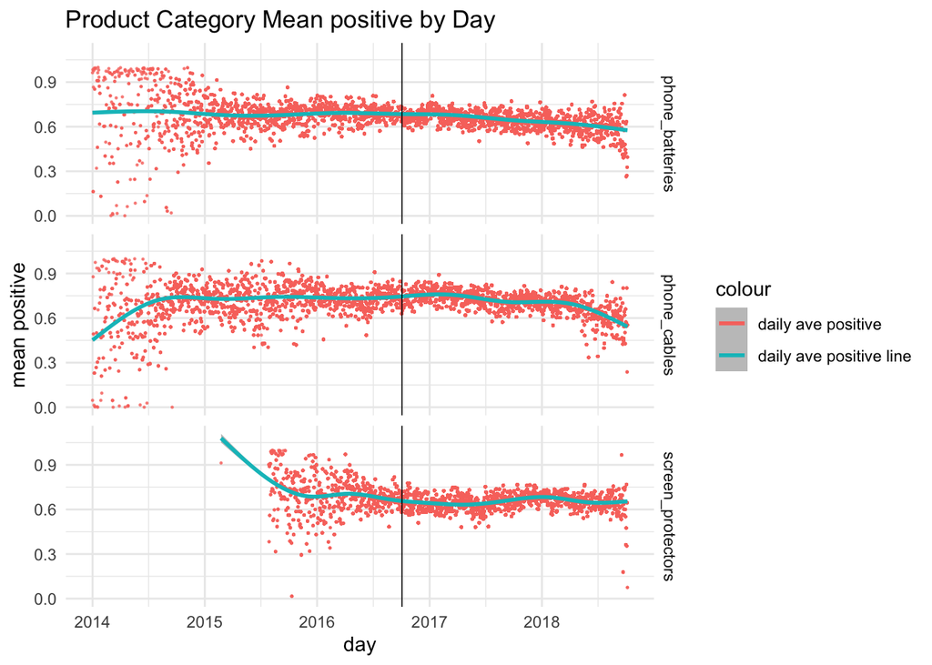

```r
## plot by day
ggplot(NULL, aes(x = date, y = day_positive))+
  geom_point(data=reviews.product, aes(color = "daily ave positive"), alpha = 0.7,size=0.2)+
  geom_smooth(data=reviews.product,method = 'auto',aes(color='daily ave positive line'),size=1,alpha = 0.6)+
  theme_minimal()+
  facet_grid(rows=vars(product_cat))+
  geom_vline(xintercept = as.Date('2016-10-03'), color = "black", size=0.3)+
  labs(x='day',y='mean positive',fill='category',title='Product Category Mean positive by Day')
```

### 3.1.2 Positive sentiment probability averaged by week

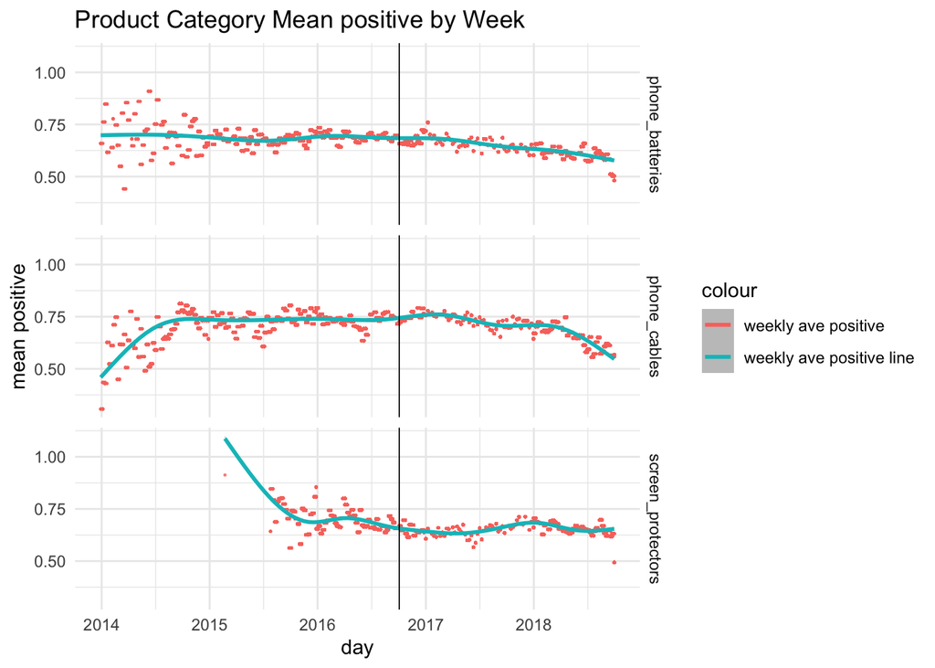

### 3.1.3 Positive sentiment probability averaged by month

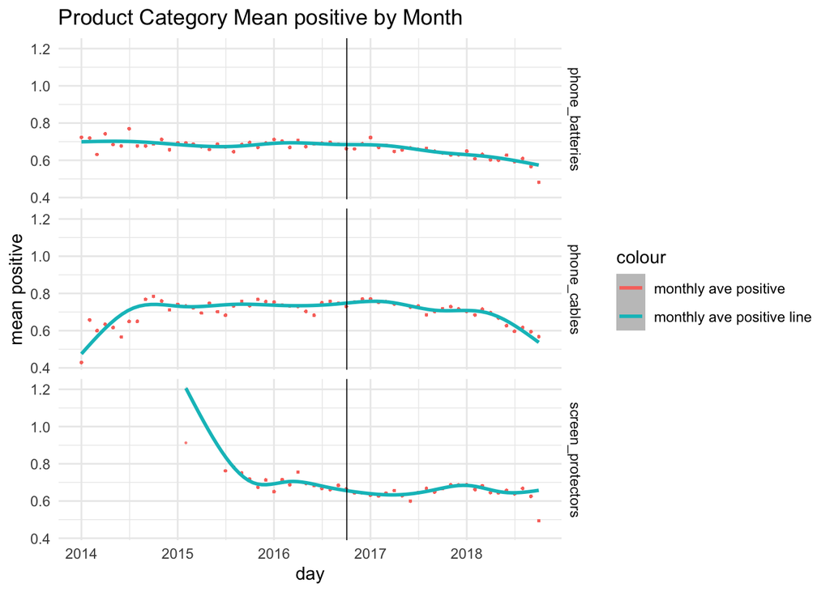

## 3.2 Plot positive sentiment probability distribution by proportion

### 3.2.1 Positive sentiment probability proportion in a day

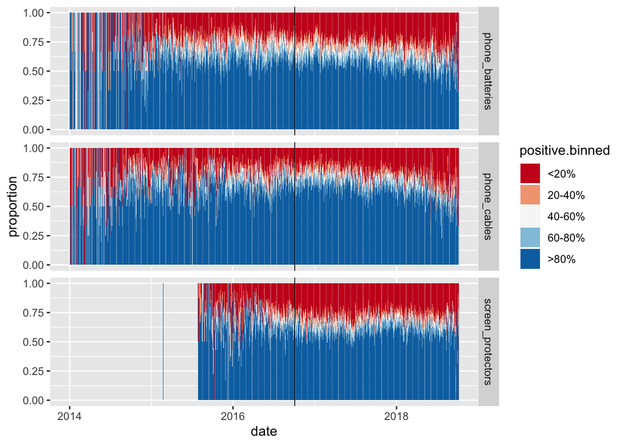

### 3.2.2 Positive sentiment probability proportion in a week

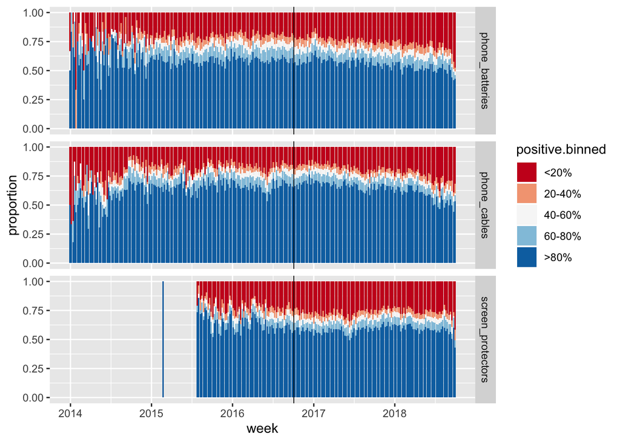

### 3.2.3 Positive sentiment probability proportion in a month

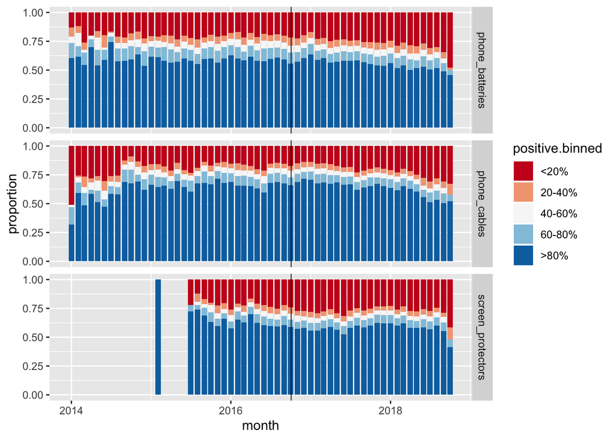

## 3.3 Plot positive sentiment probability distribution by count

### 3.3.1 Positive sentiment probability count in a day

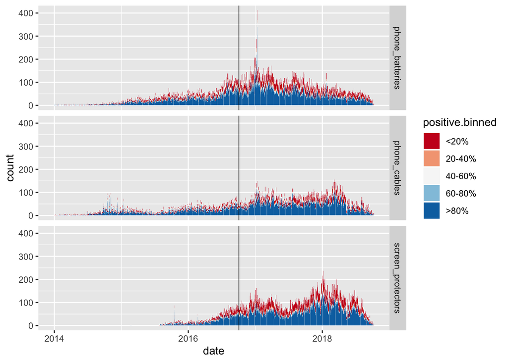

### 3.3.2 Positive sentiment probability count in a week

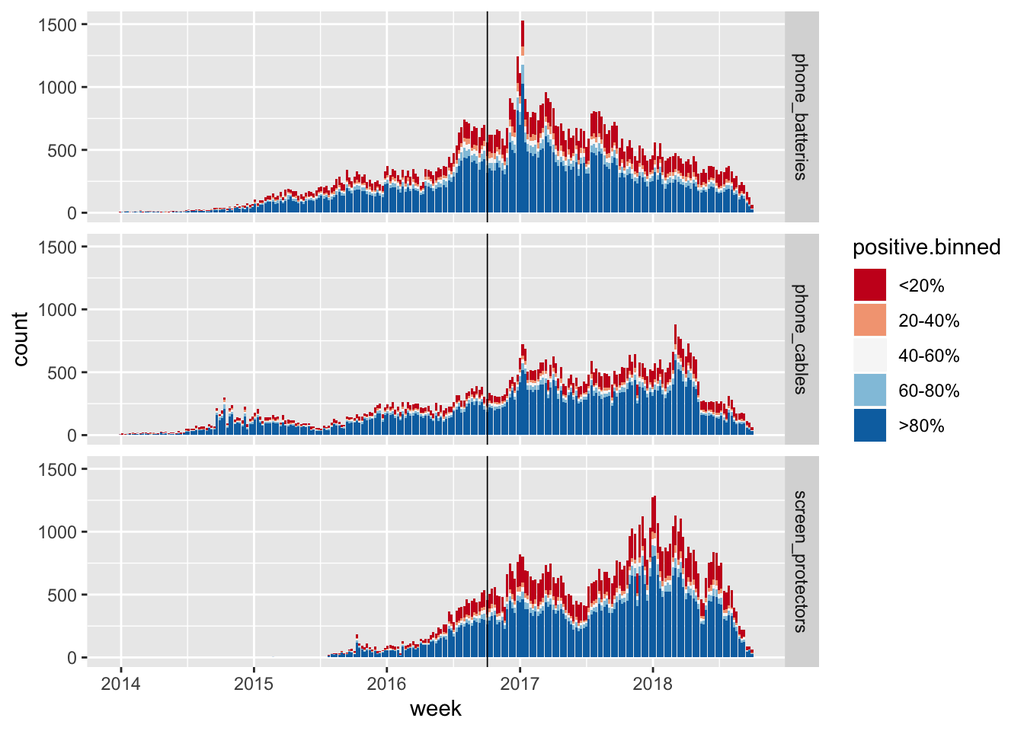

### 3.3.3 Positive sentiment probability count in a month

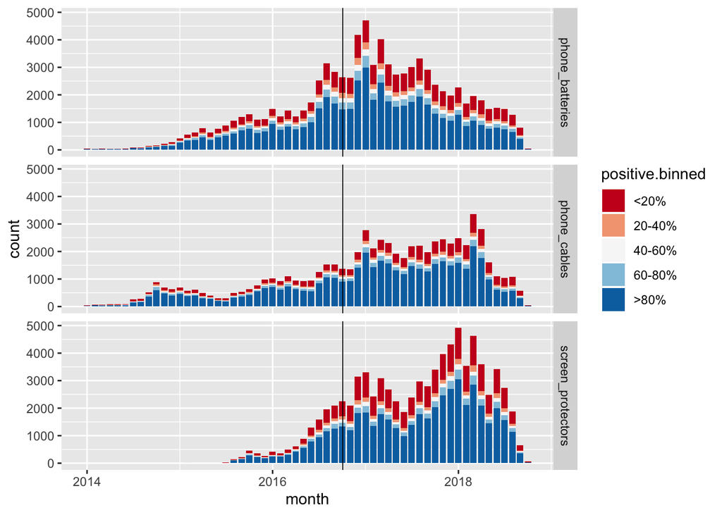

# 4 Time Data vs. Neutral Sentiment Probability

## 4.1 Plot mean neutral sentiment probability over time by product_cat without splitting incentivized vs. non-incentivized reviews at all

### 4.1.1 Neutral sentiment probability average by day

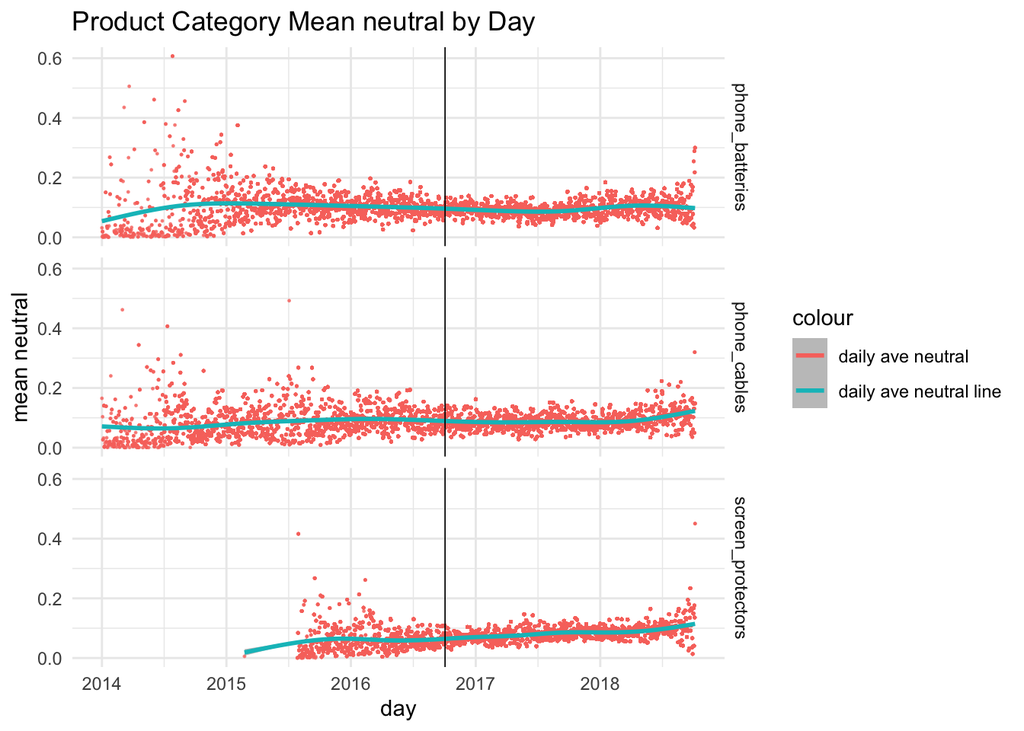

```r
## plot by day
ggplot(NULL, aes(x = date, y = day_neutral))+
  geom_point(data=reviews.product, aes(color = "daily ave neutral"), alpha = 0.7,size=0.2)+
  geom_smooth(data=reviews.product,method = 'auto',aes(color='daily ave neutral line'),size=1,alpha = 0.6)+
  theme_minimal()+
  facet_grid(rows=vars(product_cat))+
  geom_vline(xintercept = as.Date('2016-10-03'), color = "black", size=0.3)+
  labs(x='day',y='mean neutral',fill='category',title='Product Category Mean neutral by Day')
```

### 4.1.2 Neutral sentiment probability averaged by week

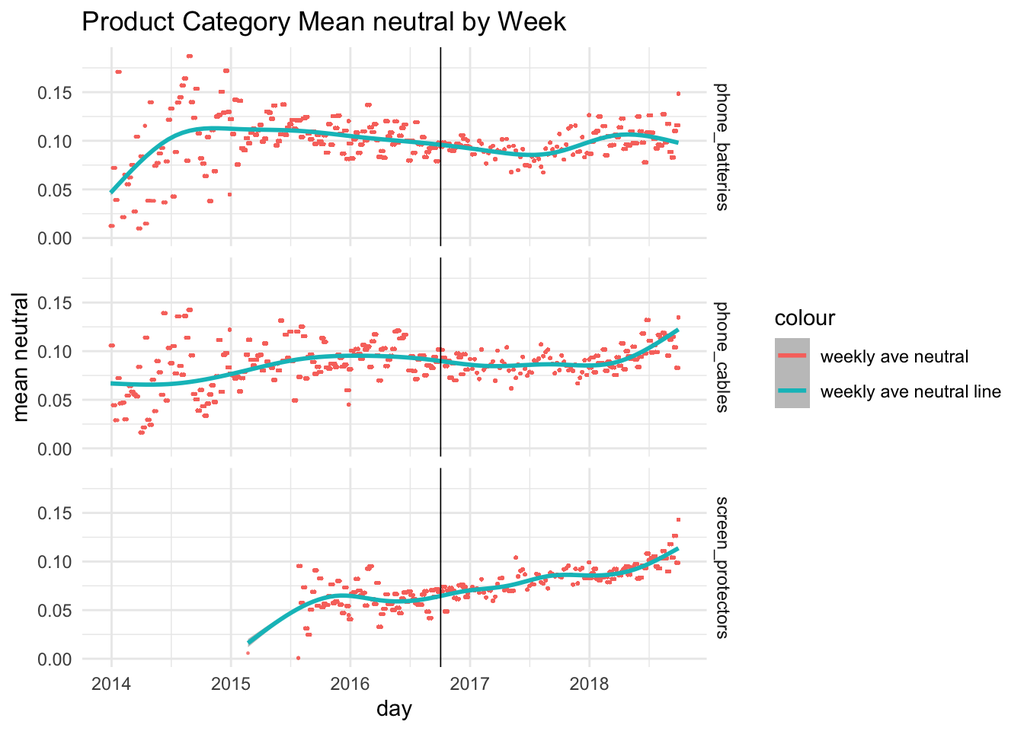

### 4.1.3 Neutral sentiment probability averaged by month

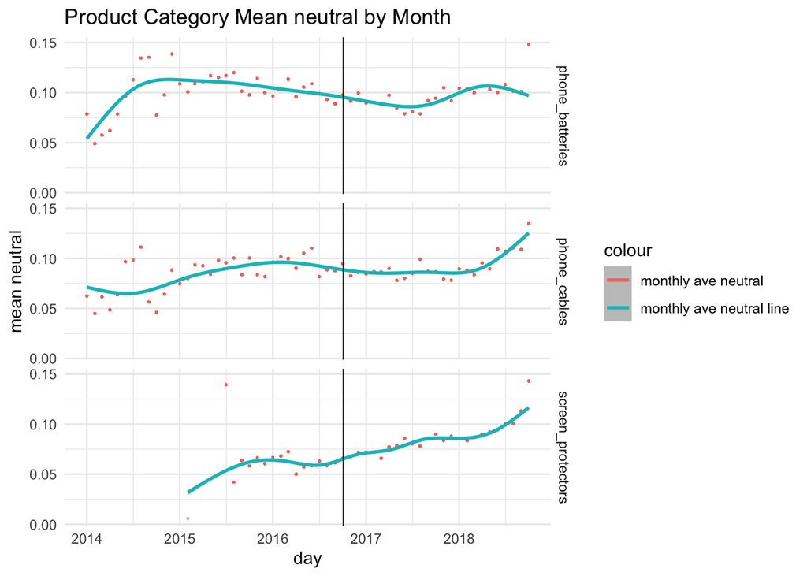

## 4.2 Plot neutral sentiment probability distribution by proportion

### 4.2.1 Neutral sentiment probability proportion in a day

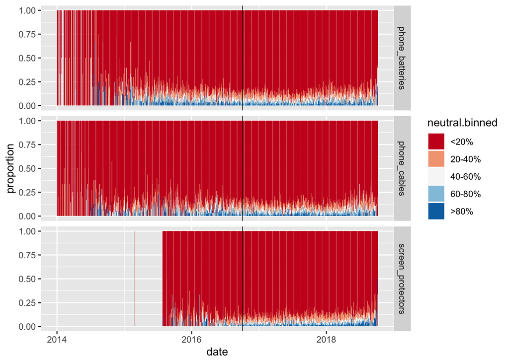

### 4.2.2 Neutral sentiment probability proportion in a week

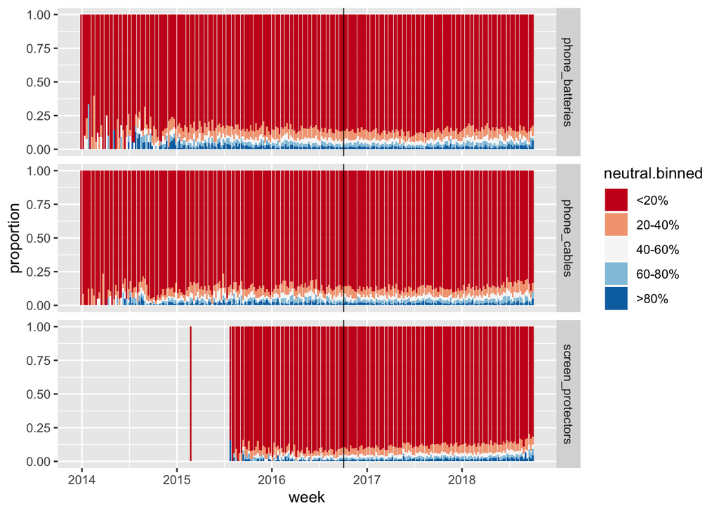

### 4.2.3 Neutral sentiment probability proportion in a month

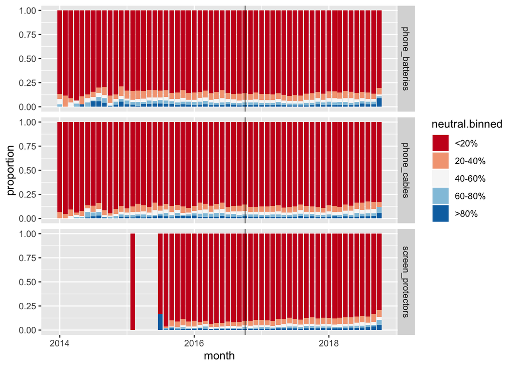

## 4.3 Plot neutral sentiment probability distribution by count

### 4.3.1 Neutral sentiment probability count in a day

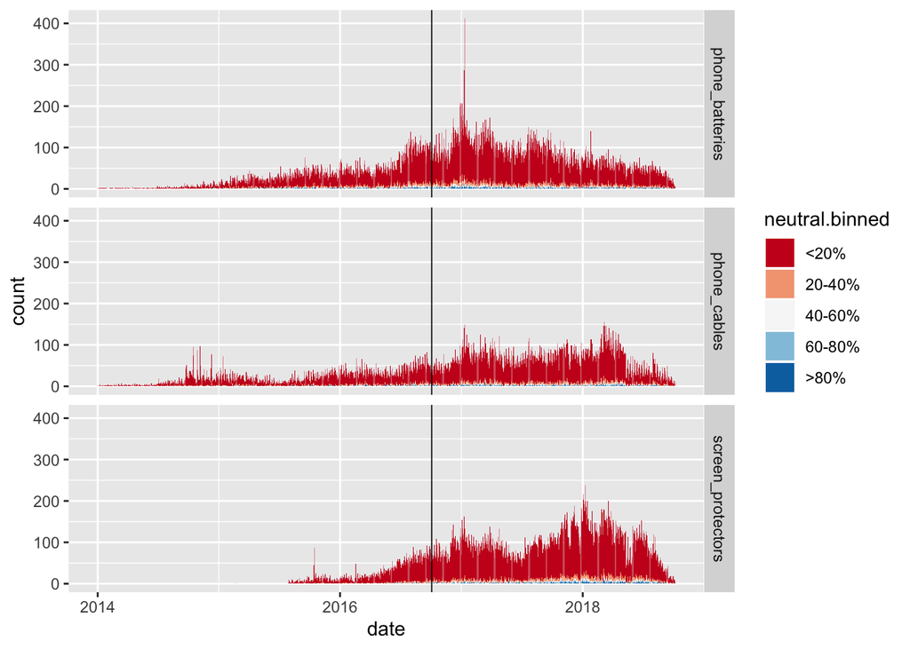

### 4.3.2 Neutral sentiment probability count in a week

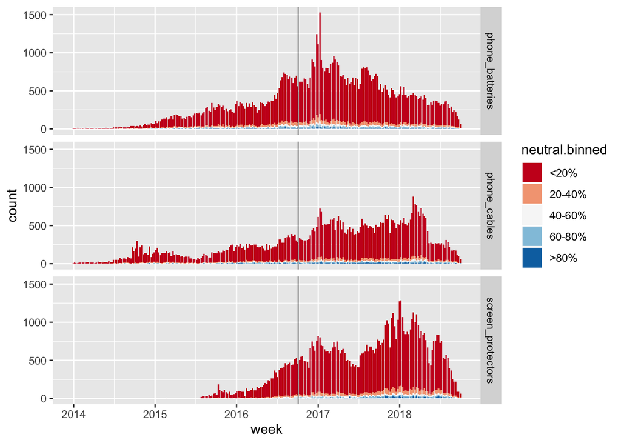

### 4.3.3 Neutral sentiment probability count in a month

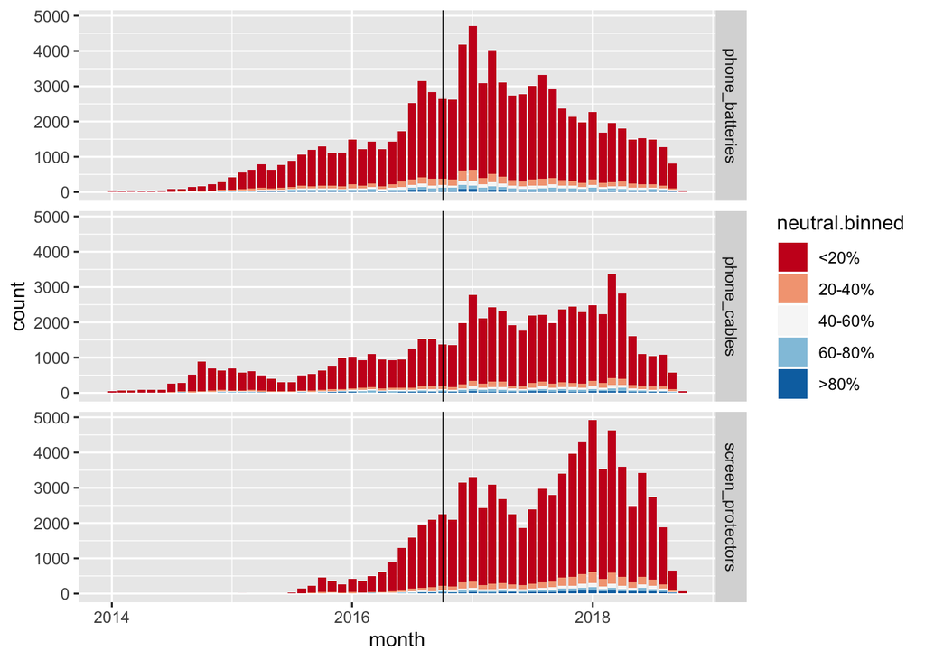